# Chapter 8: Tree-Based Methods

Matt Kosko

6/24/2018

7. In the lab, we applied random forests to the Boston data using `mtry=6` and using `ntree=25` and `ntree=500`. Create a plot displaying the test error resulting from random forests on this data set for a more comprehensive range of values for `mtry` and `ntree`. You can model your plot after Figure 8.10. Describe the results obtained.

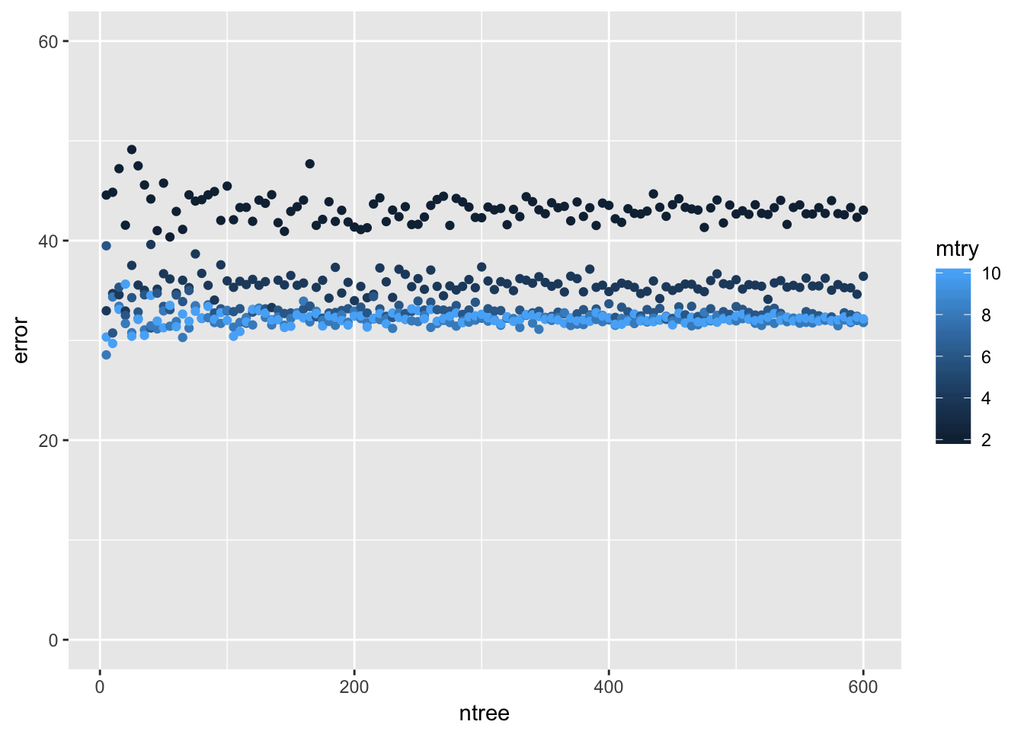

```r
set.seed(230)
tree_num1 <- seq(5, 600, by = 5)
tree_num <- do.call('c',lapply(tree_num1, rep, times = 5))
mtry_num <- rep(c(2, 4, 6, 8, 10), length(tree_num1))
train <- sample(nrow(Boston)/2)
tree_range <- function(trees, num, data, predicted, predictors, training){
  if (!missing(predictors)) {
    form <- paste0(predicted, ' ~ ', paste(predictors, collapse = ' + '))
  } else {
    form <- paste0(predicted, ' ~ .')
  }
  tree.out <- randomForest(formula = as.formula(form), data = data, ntree = trees, mtry = num, subset = training)
  preds <- predict(tree.out, newdata = data[-training, ])
  error <- mean((preds - data[-training, predicted])^2)
  c(error = error, ntree = trees, mtry = num)
}
test_errors <- map2(tree_num, mtry_num, tree_range, data = Boston, predicted = 'medv', training = train)
df <- as.data.frame(do.call(rbind, test_errors))
ggplot(df, aes(x = ntree, y = error)) + geom_point(aes(color = mtry)) + ylim(c(0,60))
```

8. In the lab, a classification tree was applied to the Carseats data set after converting Sales into a qualitative response variable. Now we will seek to predict Sales using regression trees and related approaches, treating the response as a quantitative variable.
1. Split the data set into a training set and a test set.

```r
set.seed(132)
train <- sample(1:nrow(Carseats), nrow(Carseats)/2)
Carseats.train <- Carseats[train, ]
Carseats.test <- Carseats[-train, ]
```

2. Fit a regression tree to the training set. Plot the tree, and interpret the results. What test MSE do you obtain?

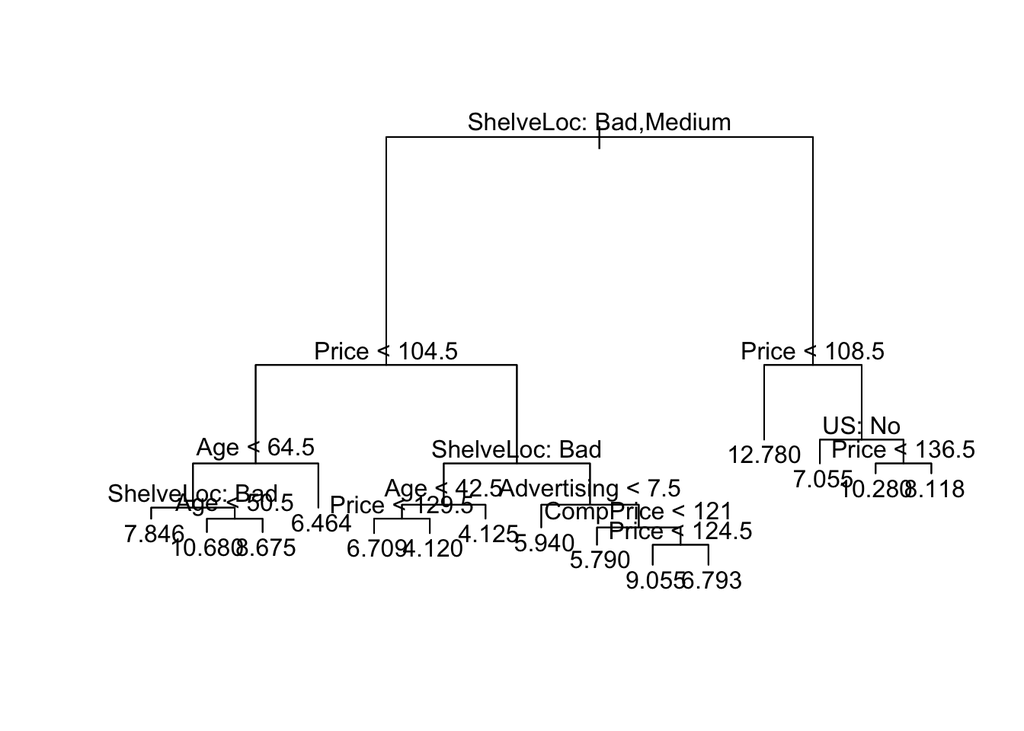

```r
tree.out <- tree(Sales ~ ., data = Carseats.train)
plot(tree.out)
text(tree.out, pretty = 0)
```

```r
preds <- predict(tree.out, new = Carseats.test)
mean((preds - Carseats.test$Sales)^2)
```

```
## [1] 4.192098
```

3. Use cross-validation in order to determine the optimal level of tree complexity. Does pruning the tree improve the test MSE?

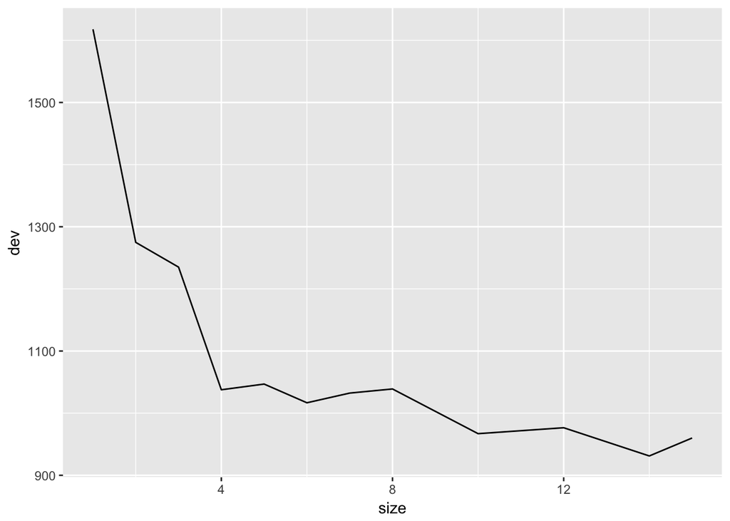

```r
cv.out <- cv.tree(tree.out)
df <- data.frame(dev = cv.out$dev, size = cv.out$size)
ggplot(df, aes(x = size, y = dev)) + geom_line()
```

```r
best <- cv.out$size[which.min(cv.out$dev)]
```

```r
prune.out <- prune.tree(tree.out, best = best)
yhat_prune <- predict(prune.out, new = Carseats.test)
yhat <- predict(tree.out, new = Carseats.test)
y <- Carseats.test$Sales
mse <- function(preds, y){
  mean((y - preds)^2)
}
paste0('Pruning the tree ', ifelse(mse(yhat_prune, y) < mse(yhat, y),'improves', 'does not improve'), ' test MSE')
```

```
## [1] "Pruning the tree does not improve test MSE"
```

4. Use the bagging approach in order to analyze this data. What test MSE do you obtain? Use the `importance()` function to determine which variables are most important.

```r
bag.out <- randomForest(Sales ~., mtry = dim(Carseats.train)[2]-1, data = Carseats.train)
yhat_bag <- predict(bag.out, new = Carseats.test)
mse(yhat_bag, y)
```

```
## [1] 2.574581
```

```r
importance(bag.out)
```

```
##             IncNodePurity
## CompPrice      144.226619
## Income          84.303076
## Advertising    108.049379
## Population      52.920658
## Price          459.469654
## ShelveLoc      491.239321
## Age            164.483165
## Education       43.757223
## Urban            5.678805
## US              12.257082
```

5. Use random forests to analyze this data. What test MSE do you obtain? Use the `importance()` function to determine which variables are most important. Describe the effect of $m$, the number of variables considered at each split, on the error rate obtained.

```r
rf.out <- randomForest(Sales ~., data = Carseats.train)
yhat_rf <- predict(rf.out, new = Carseats.test)
mse(yhat_rf, y)
```

```
## [1] 3.151078
```

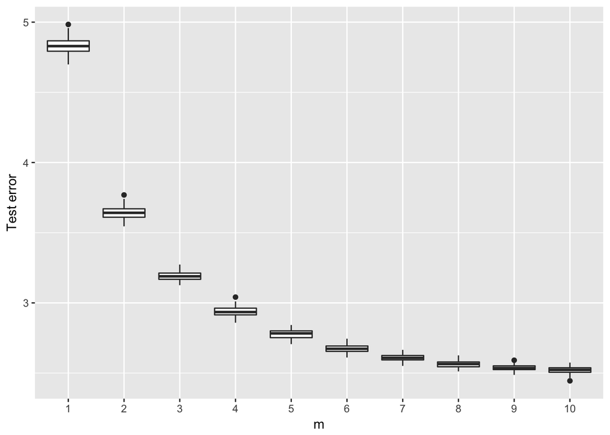

```r
m_plot <- function(m, data, newdata, y, predictors, ...){
    if (!missing(predictors)) {
    form <- paste0(y, ' ~ ', paste(predictors, collapse = ' + '))
  } else {
    form <- paste0(y, ' ~ .')
  }
  rf.out <- randomForest(formula = as.formula(form), data = data, mtry = m)
  preds <- predict(rf.out, newdata = newdata)
  error <- mean((preds - newdata[, y])^2)
  c(error = error, m = m)
}
mat <- map(rep(1:10, 100), m_plot, data = Carseats.train, newdata = Carseats.test, y = 'Sales')
df <- as.data.frame(do.call(rbind, mat))
ggplot(df, aes(x = as.factor(m), y = error)) + geom_boxplot() + xlab('m') + ylab('Test error')
```

9. This problem involves the OJ data set which is part of the ISLR package.
1. Create a training set containing a random sample of 800 observations, and a test set containing the remaining observations.

```r
data(OJ)
set.seed(432)
train <- sample(1:nrow(OJ), 800)
```

2. Fit a tree to the training data, with `Purchase` as the response and the other variables as predictors. Use the `summary()` function to produce summary statistics about the tree, and describe the results obtained. What is the training error rate? How many terminal nodes does the tree have?

```r
tree.out <- tree(Purchase ~., data = OJ, subset = train)
summ <- summary(tree.out)
summ
```

```
##
## Classification tree:
## tree(formula = Purchase ~ ., data = OJ, subset = train)
## Variables actually used in tree construction:
## [1] "LoyalCH"       "PriceDiff"     "ListPriceDiff" "SalePriceMM"
## Number of terminal nodes:  8
## Residual mean deviance:  0.7265 = 575.4 / 792
## Misclassification error rate: 0.1638 = 131 / 800
```

4. Create a plot of the tree, and interpret the results.

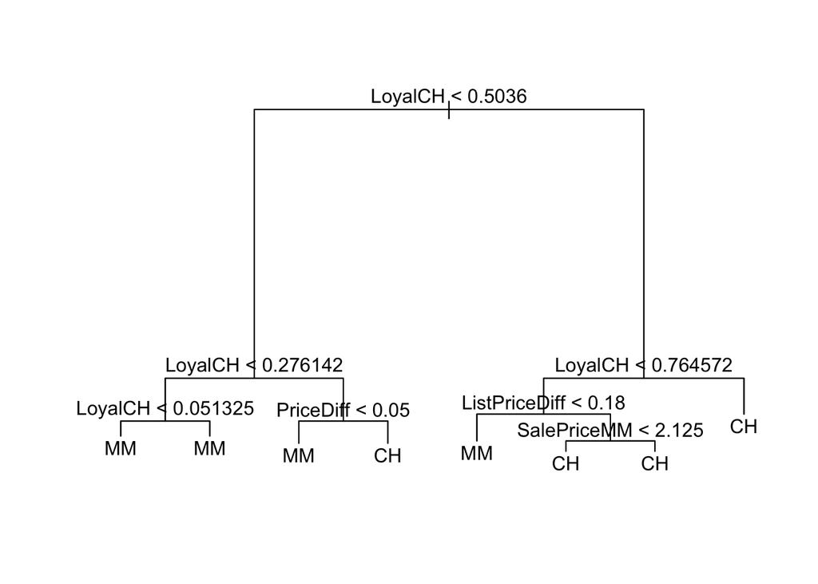

```r
plot(tree.out)
text(tree.out, pretty = 0)
```

5. Predict the response on the test data, and produce a confusion matrix comparing the test labels to the predicted test labels. What is the test error rate?

```r
preds <- predict(tree.out, new = OJ[-train, ], type = 'class')
truth <- OJ[-train, 'Purchase']
tab <- table(preds, truth)
tab
```

```
##      truth
## preds  CH  MM
##    CH 138  31
##    MM  24  77
```

```r
paste0('The test error rate is ', round((1-(tab[1,1]+tab[2,2])/270), 3))
```

```
## [1] "The test error rate is 0.204"
```

6. Apply the `cv.tree()` function to the training set in order to determine the optimal tree size.

```r
set.seed(616)
cv.out <- cv.tree(tree.out, FUN = prune.misclass)
cv.out
```

```
## $size
## [1] 8 6 4 2 1
##
## $dev
## [1] 150 150 148 163 309
##
## $k
## [1]  -Inf   0.0   2.5   8.5 156.0
##
## $method
## [1] "misclass"
##
## attr(,"class")
## [1] "prune"         "tree.sequence"
```

7. Produce a plot with tree size on the x-axis and cross-validated classification error rate on the y-axis.

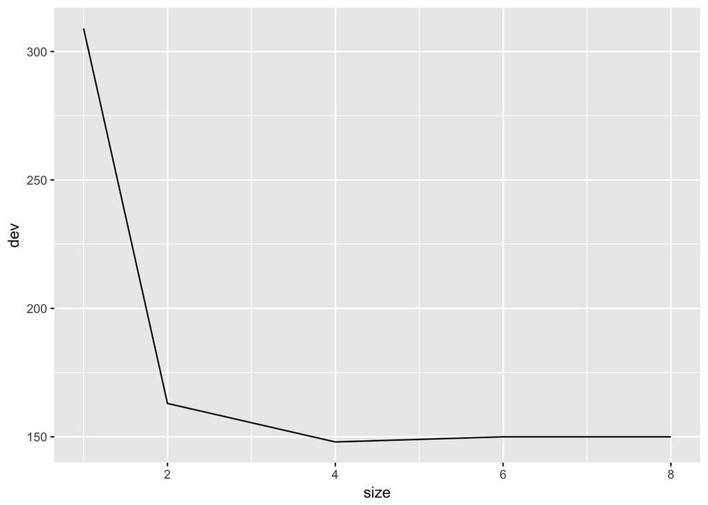

```r
df <- data.frame(dev = cv.out$dev, size = cv.out$size)
ggplot(df, aes(x = size, y = dev)) + geom_line()
```

8. Which tree size corresponds to the lowest cross-validated classification error rate?

```r
cv.out$size[which.min(cv.out$dev)]
```

```
## [1] 4
```

1. Produce a pruned tree corresponding to the optimal tree size obtained using cross-validation. If cross-validation does not lead to selection of a pruned tree, then create a pruned tree with five terminal nodes.

```r
prune.out <- prune.tree(tree.out, best = cv.out$size[which.min(cv.out$dev)])
sump <- summary(prune.out)
```

10. Compare the training error rates between the pruned and un-pruned trees. Which is higher?

```r
paste0('The training error for the pruned tree is ', ifelse(sump$misclass[1] > summ$misclass[1], 'higher', 'lower'), ' than the unpruned tree')
```

```
## [1] "The training error for the pruned tree is higher than the unpruned tree"
```

11. Compare the test error rates between the pruned and unpruned trees. Which is higher?

```r
test_error <- function(model, train, data, y, type){
  preds <- predict(model, new = data[-train, ], type = type)
  tab <- table(preds, data[-train, y])
  1-(tab[2, 2]+tab[1, 1])/dim(data[-train, ])[1]
}
te <- test_error(tree.out, train = train, data = OJ, y = 'Purchase', type = 'class')
pe <- test_error(prune.out, train = train, data = OJ, y = 'Purchase', type = 'class')
paste0('The test error for the pruned tree is ', ifelse(pe > te, 'higher', 'lower'), ' than the unpruned tree')
```

```
## [1] "The test error for the pruned tree is higher than the unpruned tree"
```

10. We now use boosting to predict Salary in the Hitters data set.
1. Remove the observations for whom the salary information is unknown, and then log-transform the salaries.

```r
data(Hitters)
Hitters <- Hitters %>% filter(!is.na(Salary)) %>% mutate(Salary = log(Salary))
```

2. Create a training set consisting of the first 200 observations, and a test set consisting of the remaining observations.

```r
set.seed(666)
train <-sample(1:nrow(Hitters), 200)
```

3. Perform boosting on the training set with 1,000 trees for a range of values of the shrinkage parameter $\lambda$. Produce a plot with different shrinkage values on the x-axis and the corresponding training set MSE on the y-axis.

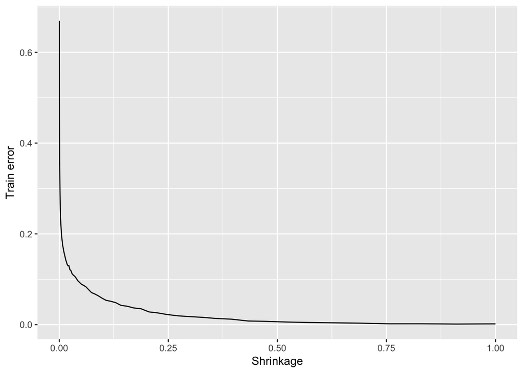

```r
boost <- function(lambda, y, predictors, train, data, distribution, ntrees, test = TRUE){
    if (!missing(predictors)) {
    form <- paste0(y, ' ~ ', paste(predictors, collapse = ' + '))
  } else {
    form <- paste0(y, ' ~ .')
  }
  gbm.out <- gbm(formula = as.formula(form), data = data[train, ], distribution = distribution, n.trees = ntrees, shrinkage = lambda)
  if (test){
    preds <- predict(gbm.out, newdata = data[-train, ], n.trees = ntrees)
    error <- mean((preds - data[-train, y])^2)
  } else {
    preds <- predict(gbm.out,  n.trees = ntrees)
    error <- mean((preds - data[train, y])^2)
  }
  c(error = error, lambda = lambda)
}
train_df <- map(10^seq(0,-4,length=100), boost, y = 'Salary', train = train, data = Hitters, ntrees = 1000, distribution = 'gaussian', test = FALSE)
train_df <- as.data.frame(do.call(rbind, train_df))
ggplot(train_df, aes(x = lambda, y = error)) + geom_line() + ylab('Train error') + xlab('Shrinkage')
```

4. Produce a plot with different shrinkage values on the x-axis and the corresponding test set MSE on the y-axis.

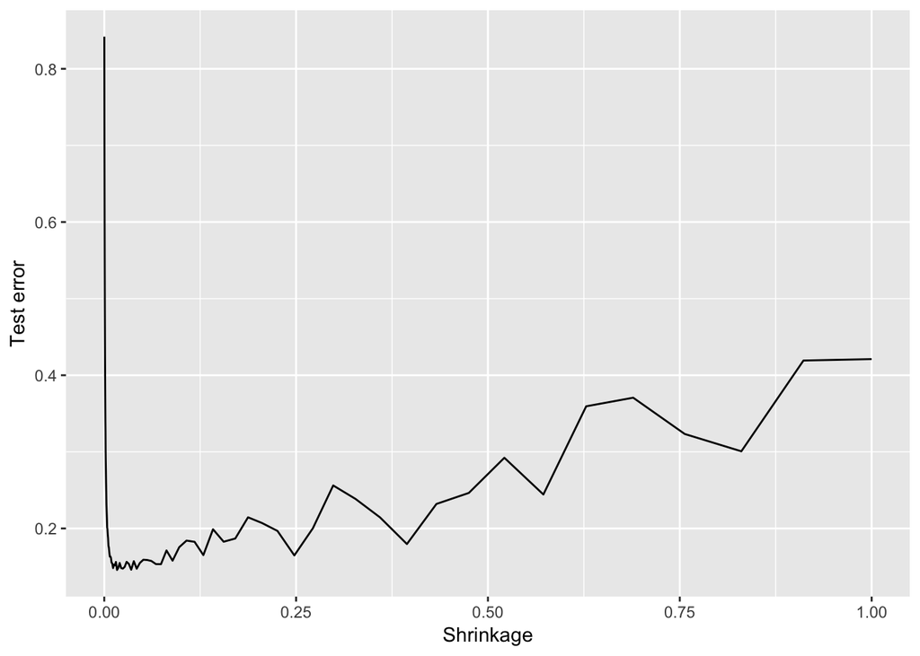

```r
test_df <- map(10^seq(0,-4,length=100), boost, y = 'Salary', train = train, data = Hitters, ntrees = 1000, distribution = 'gaussian', test = TRUE)
test_df <- as.data.frame(do.call(rbind, test_df))
ggplot(test_df, aes(x = lambda, y = error)) + geom_line() + ylab('Test error') + xlab('Shrinkage')
```

5. Compare the test MSE of boosting to the test MSE that results from applying two of the regression approaches seen in Chapters 3 and 6.

```r
lm.out <- lm(Salary ~., data = Hitters, subset = train)
preds <- predict(lm.out, newdata = Hitters[-train, ])
mean((Hitters[-train, 'Salary']-preds)^2)
```

```
## [1] 0.394736
```

```r
x <- model.matrix(Salary ~., data = Hitters)[, -1]
y <- Hitters$Salary
cvglm <- cv.glmnet(x[train, ], y[train], alpha = 1)
lasso.out <- glmnet(x[train, ], y[train], alpha = 1)
preds <- predict(lasso.out, newx = x[-train, ], s = cvglm$lambda.min)
mean((preds-y[-train])^2)
```

```
## [1] 0.3954259
```

6. Which variables appear to be the most important predictors in the boosted model?

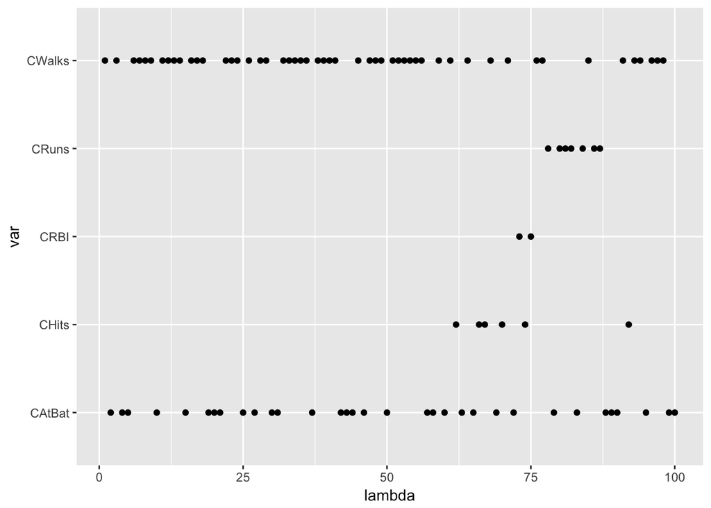

```r
boost_importance <- function(lambda, y, predictors, train, data, distribution, ntrees){
    if (!missing(predictors)) {
    form <- paste0(y, ' ~ ', paste(predictors, collapse = ' + '))
  } else {
    form <- paste0(y, ' ~ .')
  }
  gbm.out <- gbm(formula = as.formula(form), data = data[train, ], distribution = distribution, n.trees = ntrees, shrinkage = lambda)
  sumb <- summary(gbm.out, plotit = FALSE)
  most_important <- as.character(sumb$var[1])
  c(var = most_important, lambda = as.numeric(lambda))
}
df <- map(10^seq(0,-4,length=100), boost_importance, y = 'Salary', train = train, data = Hitters, distribution = 'gaussian', ntrees = 100)
df <- as.data.frame(do.call(rbind, df))
df$lambda <- as.numeric(df$lambda)
ggplot(df, aes(x = lambda, y = var)) + geom_point()
```

```r
data(Caravan)
set.seed(4382)
train <- sample(1:nrow(Caravan), 1000)
```

2. Fit a boosting model to the training set with `Purchase` as the response and the other variables as predictors. Use 1,000 trees, and a shrinkage value of 0.01. Which predictors appear to be the most important?

```r
Caravan$Purchase <- ifelse(Caravan$Purchase == 'Yes', 1, 0)
gbm.out <- gbm(Purchase ~., data = Caravan[train, ], n.trees = 1000, shrinkage = 0.01, distribution = 'bernoulli')
head(summary(gbm.out, plotit = FALSE))
```

```
##               var   rel.inf
## PPERSAUT PPERSAUT 12.641299
## APERSAUT APERSAUT 12.151791
## MOSTYPE   MOSTYPE  9.588562
## PBRAND     PBRAND  7.873550
## MBERHOOG MBERHOOG  6.005016
## MSKA         MSKA  4.873970
```

3. Use the boosting model to predict the response on the test data. Predict that a person will make a purchase if the estimated probability of purchase is greater than 20%. Form a confusion matrix. What fraction of the people predicted to make a purchase do in fact make one? How does this compare with the results obtained from applying KNN or logistic regression to this data set?

```r
preds <- predict(gbm.out, n.trees = 1000, type = 'response')
purchase <- ifelse(preds > 0.20, 1, 0)
tab <- table(purchase, Caravan[train, 'Purchase'])
tab
```

```
##
## purchase   0   1
##        0 899  40
##        1  35  26
```

```r
tab[2, 2]/(tab[2, 1] + tab[2, 2])
```

```
## [1] 0.4262295
```

```r
standard.X <- scale(Caravan[, -86])
knn.out <- knn(standard.X[train, ], standard.X[-train, ], Caravan[train, 'Purchase'], k = 3)
tab <- table(knn.out, Caravan[-train, 'Purchase'])
tab
```

```
##
## knn.out    0    1
##       0 4469  266
##       1   71   16
```

```r
tab[2, 2]/(tab[2, 1] + tab[2, 2])
```

```
## [1] 0.183908
```